# Cultivares - Trabalho Final

Pedro Portela

25 de junho de 2018

### Wine dataset

Para este experimento, os dados registram características de vinhos cultivados na mesma região na Itális, mas derivados de três diferentes *cultivares*.

Cultivares são espécies de plantas que foram melhoradas devido à alteração ou introdução de uma característica que antes não possuíam. Elas se distinguem das outras variedades da mesma espécie por homogeneidade, estabilidade e novidade.

Temos um conjunto de dados com 13 atributos com valores contínuos e mais um atributo (V1) com rótulos de classe de origem do vinho (cultivares). Usando o *wine dataset*, nesse relatório será apresentado um modelo para reconhecer a origem do vinho a partir das suas características, usando KNN.

[output not shown]

#### Análise exploratória

A seguir, repectivamente: estrutura de dados; informações gerais das variáveis e mapa de valores.

```
## 'data.frame':    178 obs. of  14 variables:
##  $ V1 : Factor w/ 3 levels "1","2","3": 1 1 1 1 1 1 1 1 1 1 ...
##  $ V2 : num  14.2 13.2 13.2 14.4 13.2 ...
##  $ V3 : num  1.71 1.78 2.36 1.95 2.59 1.76 1.87 2.15 1.64 1.35 ...
##  $ V4 : num  2.43 2.14 2.67 2.5 2.87 2.45 2.45 2.61 2.17 2.27 ...
##  $ V5 : num  15.6 11.2 18.6 16.8 21 15.2 14.6 17.6 14 16 ...
##  $ V6 : int  127 100 101 113 118 112 96 121 97 98 ...
##  $ V7 : num  2.8 2.65 2.8 3.85 2.8 3.27 2.5 2.6 2.8 2.98 ...
##  $ V8 : num  3.06 2.76 3.24 3.49 2.69 3.39 2.52 2.51 2.98 3.15 ...
##  $ V9 : num  0.28 0.26 0.3 0.24 0.39 0.34 0.3 0.31 0.29 0.22 ...
##  $ V10: num  2.29 1.28 2.81 2.18 1.82 1.97 1.98 1.25 1.98 1.85 ...
##  $ V11: num  5.64 4.38 5.68 7.8 4.32 6.75 5.25 5.05 5.2 7.22 ...
##  $ V12: num  1.04 1.05 1.03 0.86 1.04 1.05 1.02 1.06 1.08 1.01 ...
##  $ V13: num  3.92 3.4 3.17 3.45 2.93 2.85 3.58 3.58 2.85 3.55 ...
##  $ V14: int  1065 1050 1185 1480 735 1450 1290 1295 1045 1045 ...
```

```
##  V1           V2              V3              V4              V5
##  1:59   Min.   :11.03   Min.   :0.740   Min.   :1.360   Min.   :10.60
##  2:71   1st Qu.:12.36   1st Qu.:1.603   1st Qu.:2.210   1st Qu.:17.20
##  3:48   Median :13.05   Median :1.865   Median :2.360   Median :19.50
##         Mean   :13.00   Mean   :2.336   Mean   :2.367   Mean   :19.49
##         3rd Qu.:13.68   3rd Qu.:3.083   3rd Qu.:2.558   3rd Qu.:21.50
##         Max.   :14.83   Max.   :5.800   Max.   :3.230   Max.   :30.00
##        V6               V7              V8              V9
##  Min.   : 70.00   Min.   :0.980   Min.   :0.340   Min.   :0.1300
##  1st Qu.: 88.00   1st Qu.:1.742   1st Qu.:1.205   1st Qu.:0.2700
##  Median : 98.00   Median :2.355   Median :2.135   Median :0.3400
##  Mean   : 99.74   Mean   :2.295   Mean   :2.029   Mean   :0.3619
##  3rd Qu.:107.00   3rd Qu.:2.800   3rd Qu.:2.875   3rd Qu.:0.4375
##  Max.   :162.00   Max.   :3.880   Max.   :5.080   Max.   :0.6600
##       V10             V11              V12              V13
##  Min.   :0.410   Min.   : 1.280   Min.   :0.4800   Min.   :1.270
##  1st Qu.:1.250   1st Qu.: 3.220   1st Qu.:0.7825   1st Qu.:1.938
##  Median :1.555   Median : 4.690   Median :0.9650   Median :2.780
##  Mean   :1.591   Mean   : 5.058   Mean   :0.9574   Mean   :2.612
##  3rd Qu.:1.950   3rd Qu.: 6.200   3rd Qu.:1.1200   3rd Qu.:3.170
##  Max.   :3.580   Max.   :13.000   Max.   :1.7100   Max.   :4.000
##       V14
##  Min.   : 278.0
##  1st Qu.: 500.5
##  Median : 673.5
##  Mean   : 746.9
##  3rd Qu.: 985.0
##  Max.   :1680.0
```

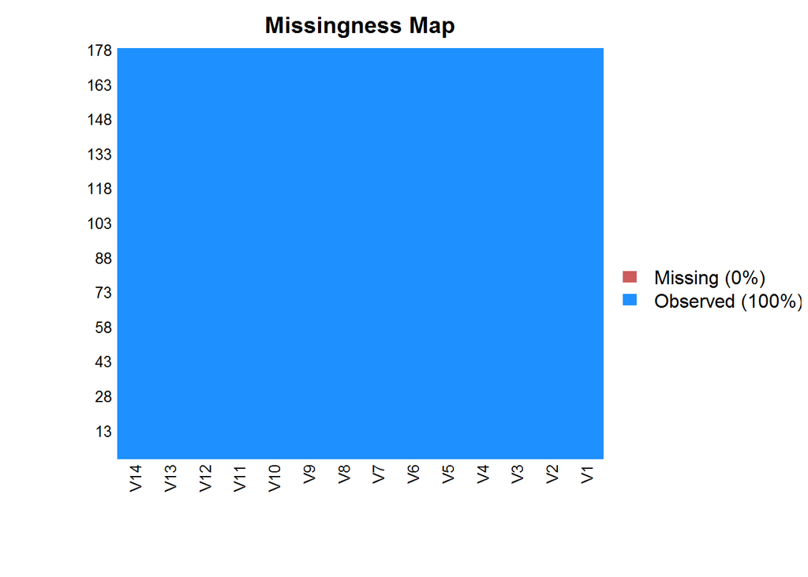

Como não existem dados NA, faz-se diretamente a seperação em dados de treinamento (75%) e teste (25%). Espera-se que as variáveis mesmo quando separadas se comportem de forma parecida, como mostra o gráfico de densidade de probabilidade da variável *V2*.

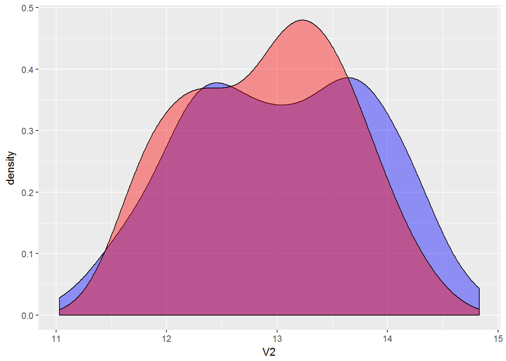

#### Modelo knn - usando o pacote caret

```r
ctrl <- trainControl(method='repeatedcv', repeats = 3)

knnFit <- train(V1 ~ V2 + V3 + V4 + V5 + V6 + V7 + V8 + V9 + V10 + V11 + V12 + V13 + V14,
                data = training, method = 'knn',
                trControl = ctrl,
                preProcess = c('center', 'scale'),
                tuneLength = 20)

knnFit
```

```
## k-Nearest Neighbors
##
## 135 samples
##  13 predictor
##   3 classes: '1', '2', '3'
##
## Pre-processing: centered (13), scaled (13)
## Resampling: Cross-Validated (10 fold, repeated 3 times)
## Summary of sample sizes: 122, 122, 122, 120, 121, 123, ...
## Resampling results across tuning parameters:
##
##   k   Accuracy   Kappa
##    5  0.9542430  0.9311131
##    7  0.9514103  0.9269890
##    9  0.9540293  0.9307493
##   11  0.9540293  0.9307493
##   13  0.9538462  0.9303797
##   15  0.9539744  0.9307404
##   17  0.9584493  0.9374777
##   19  0.9632357  0.9446232
##   21  0.9652747  0.9477115
##   23  0.9686081  0.9526841
##   25  0.9761416  0.9638940
##   27  0.9779670  0.9666340
##   29  0.9805311  0.9705030
##   31  0.9827534  0.9738364
##   33  0.9725946  0.9586659
##   35  0.9678083  0.9514977
##   37  0.9657692  0.9483597
##   39  0.9633639  0.9446543
##   41  0.9738645  0.9604748
##   43  0.9639438  0.9453904
##
## Accuracy was used to select the optimal model using the largest value.
## The final value used for the model was k = 31.
```

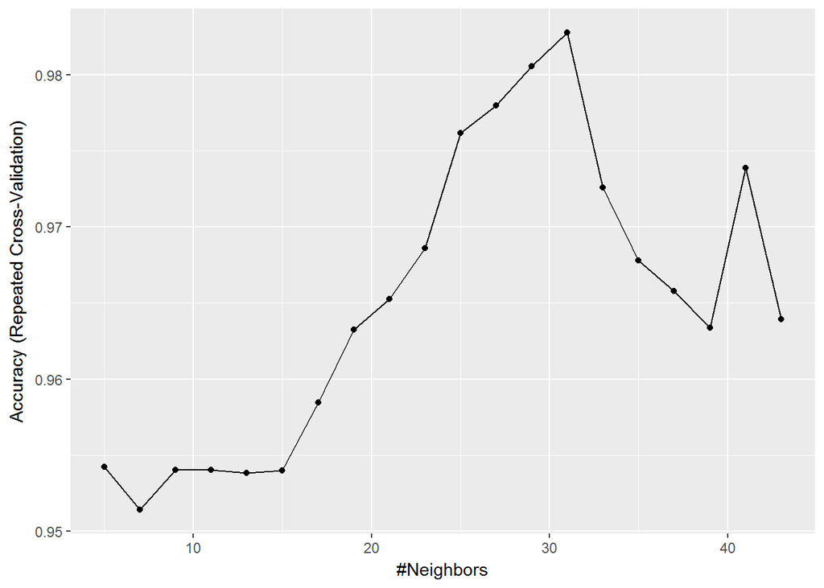

```r
ggplot(knnFit)
```

Como o padrão utiliza apenas valores ímpares, podemos explorar a vizinhança do melhor k obtido até então.

```r
gridK <- expand.grid(k=c(30:32))

knnFit2 <- train(V1 ~ V2 + V3 + V4 + V5 + V6 + V7 + V8 + V9 + V10 + V11 + V12 + V13 + V14,
                data = training, method = 'knn',
                trControl = ctrl,
                preProcess = c('center', 'scale'),
                tuneGrid = gridK)
knnFit2
```

```
## k-Nearest Neighbors
##
## 135 samples
##  13 predictor
##   3 classes: '1', '2', '3'
##
## Pre-processing: centered (13), scaled (13)
## Resampling: Cross-Validated (10 fold, repeated 3 times)
## Summary of sample sizes: 122, 122, 122, 122, 120, 122, ...
## Resampling results across tuning parameters:
##
##   k   Accuracy   Kappa
##   30  0.9733089  0.9597305
##   31  0.9731502  0.9596052
##   32  0.9703724  0.9554550
##
## Accuracy was used to select the optimal model using the largest value.
## The final value used for the model was k = 30.
```

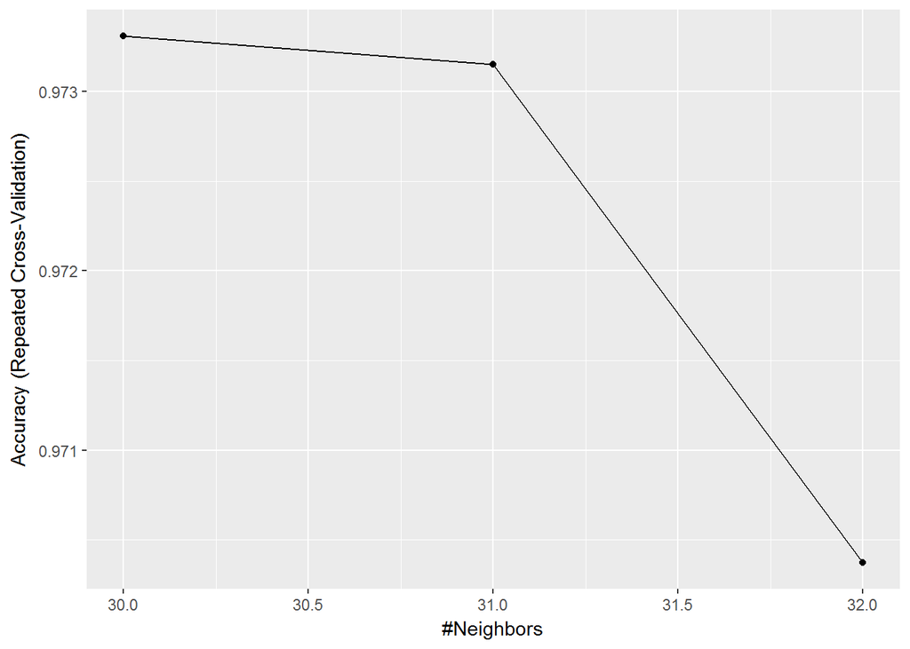

```r
ggplot(knnFit2)
```

Após uma análise mais próxima, percebe-se que na verdade o valor de k de melhor desempenho é 30. Temos então a matriz de confusão:

```r
confusionMatrix(knnFit2)
```

```
## Cross-Validated (10 fold, repeated 3 times) Confusion Matrix
##
## (entries are percentual average cell counts across resamples)
##
##           Reference
## Prediction    1    2    3
##          1 33.3  2.0  0.0
##          2  0.0 37.3  0.0
##          3  0.0  0.7 26.7
##
##  Accuracy (average) : 0.9728
```

#### Testando o modelo

Utilizando os dados de teste, a matriz de confusão a seguir demonstra a performance do modelo.

```r
knnPrediction <- predict(knnFit2, newdata=test)
confusionMatrix(knnPrediction, test$V1)
```

```
## Confusion Matrix and Statistics
##
##           Reference
## Prediction  1  2  3
##          1 14  1  0
##          2  0 15  0
##          3  0  1 12
##
## Overall Statistics
##
##                Accuracy : 0.9535
##                  95% CI : (0.8419, 0.9943)
##     No Information Rate : 0.3953
##     P-Value [Acc > NIR] : 1.02e-14
##
##                   Kappa : 0.93
##  Mcnemar's Test P-Value : NA
##
## Statistics by Class:
##
##                      Class: 1 Class: 2 Class: 3
## Sensitivity            1.0000   0.8824   1.0000
## Specificity            0.9655   1.0000   0.9677
## Pos Pred Value         0.9333   1.0000   0.9231
## Neg Pred Value         1.0000   0.9286   1.0000
## Prevalence             0.3256   0.3953   0.2791
## Detection Rate         0.3256   0.3488   0.2791
## Detection Prevalence   0.3488   0.3488   0.3023
## Balanced Accuracy      0.9828   0.9412   0.9839
```

O modelo teve boa performance também para os dados de teste, errando apenas duas observações.